[figure not shown]

**МИНОБРНАУКИ РОССИИ**

Федеральное государственное бюджетное образовательное учреждение

высшего образования

**«МИРЭА - Российский технологический университет»**

**РТУ МИРЭА**

Отчет по лабораторной работе на тему: **«Получение информации с помощью 2ip.ru, Nmap, Linkonavt.ru, REG.ru»**

Выполнил:

студент 4 курса специальности 10.05.05,

группы ББСО-02-16

Хохлова М.С.

Проверил:

Захарчук И.И.

**Москва 2020**

*Цель работы:*  
**1.Выбрать 5 компаний из списка S&P 500**  
**2. Собрать о них информацию**  
**3. Составить таблицу**

*Исходные данные:*  
1.**Asus Zenbook K46CB, Windows 10 Pro, сборка 1803**  
2.**VM Kali linux**  
3. **Web-sites 5 компаний**

*Инструменты:* Для поиска данных будем исполльзовать:

| Название | Назначение |
| --- | --- |
| [2ip.ru](https://2ip.ru/) | портал сетевых сервисов |
| [Nmap](https://nmap.online/) | утилита, предназначеная для сканирования ip-сетей, определение состояния сети (портов и сетевых служб) |
| [REG.ru](https://www.reg.ru/) | регистрация доменных имен |
| [Linkonavt.ru](https://linkonavt.ru/services/sitetechnologies) | определение используемых web-приложений |

*Общий план выполнения:*  
1.**Выбрать 5 компаний**

| Название | Сектор деятельности |
| --- | --- |
| Southwest Airlines Co. | Авиакомпания |
| Estee Lauder Companies Inc. Class A | Средства по уходу |
| Anadarko Petroleum Corporation | Энергия |
| American Electric Power Company Inc. | Электричество |
| Equinix Inc. | Недвижимость |

2.**С помощью сервиса 2ip.ru определим следующие признаки:**

- *ip-адрес*
- *Местонахождение*
- *Телефон*
- *e-mail*

3.**Просканируем порты, используя операционную систему Linux, выполнив команду:**

```
nmap <домен_компании>/<ip_адрес> -p <номер_порта>
```

4.**При помощи сервиса REG.ru определим кто занимается хостингом данной компании;**  
**4) Используем Linkonavt.ru, чтобы определить web-приложения по домену.**

*Сведения о компаниях:*  
*Southwest Airlines Co.*

Признак

Значение

Сайт

[southwest.com](https://www.southwest.com/)

ip-адрес

66.150.1.229

Местонахождение

United States, Dallas (Southwest Airlines P.O. Box 36647-1CR Dallas, Texas 75235)

Телефон

1-800-I-FLY-SWA (1-800-435-9792)

e-mail

domainrequest@wnco.com

порты

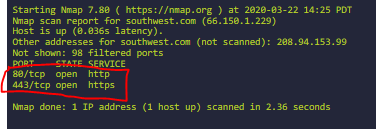

хостинг

Name Server: ns-pdc.southwest.com; Name Server: ns-sdc.southwest.com

*Estee Lauder Companies Inc. Class A.*

Признак

Значение

Сайт

[elcompanies.com](https://www.elcompanies.com/en)

ip-адрес

52.17.142.199

Местонахождение

US, NY

Телефон

+1.2083895770

e-mail

abusecomplaints@markmonitor.com

порты

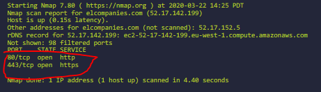

хостинг

Name Server: ns3.elcompanies.com; Name Server: ns4.elcompanies.com; Name Server: ns2.elcompanies.com; Name Server: ns5.elcompanies.com

web-приложения

[figure not shown]

*Anadarko Petroleum Corporation*

Признак

Значение

Сайт

[anadarko.com](http://www.anadarko.com/)

ip-адрес

192.237.142.161

Местонахождение

United States, Texas (5 Greenway Plaza, Suite 110 Houston, Texas)

Телефон

+1.3026365400

e-mail

domainabuse@cscglobal.com

порты

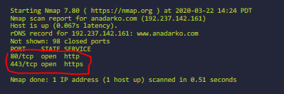

хостинг

Name Server: ns6.dnsmadeeasy.com; Name Server: ns5.dnsmadeeasy.com; Name Server: ns4.p05.dynect.net; Name Server: ns7.dnsmadeeasy.com; Name Server: ns2.p05.dynect.net; Name Server: ns3.p05.dynect.net; Name Server: ns1.p05.dynect.net

web-приложения

[figure not shown]

*American Electric Power Company Inc.*

Признак

Значение

Сайт

[aep.com](http://www.aep.com/)

ip-адрес

167.239.226.24

Местонахождение

United States, Columbus

Телефон

+1.2083895770

e-mail

abusecomplaints@markmonitor.com

порты

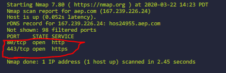

хостинг

Name Server: ns3.aep.com; Name Server: ns4.aep.com

web-приложения

[figure not shown]

*Equinix Inc.*

Признак

Значение

Сайт

[equinix.com](https://www.equinix.com/)

ip-адрес

216.221.225.13

Местонахождение

United States, Redwood City

Телефон

+1.8887802723

e-mail

domainabuse@cscglobal.com

порты

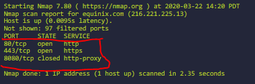

хостинг

Name Server: edns116.ultradns.com; Name Server: edns116.ultradns.org; Name Server: edns116.ultradns.biz; Name Server: edns116.ultradns.net

web-приложения

[figure not shown]

**Вывод:**  
С помощью сервисов 2ip.ru,Nmap, Linkonavt.ru,REG.ru, Linkonavt.ru, получили различную информацию(телефон, местонахождение,e-mail, порты, web-приложения, хостинг, ip-адрес) об организациях. В дальнейшем можно использовать для раличных атак.